# Développement des pays d’Afrique en 2018

Dossier : africa_pays_2018

Auteur·rice

Claude Grasland

Date de publication

2025-03-28

**Télécharger le jeu de données**

- [Cliquer ici](https://github.com/worldregio/afromapr/raw/refs/heads/main/datazip/africa_pays_2018.zip)

### Source

Cette base de données statistique sur le développement des pays d’Afrique en 2018 est un basée sur les rapport sur le développement humain de 2020, complété par quelques données de cadrages du CEPII. Le fonds de carte est issu quant à lui de la base Natural Earth. Le fichier est à citer comme suit :

> **Données** : HDR 2020, & CEPII / **Fonds de carte** : Natural Earth

### Indicateurs

| Code | Definition | Souce |
| --- | --- | --- |
| iso3 | ISO3 code of country | Human Development Report 2020 |
| name | English name of country | Human Development Report 2020 |
| nom | French name of country | Human Development Report 2020 |
| POP | Population (Millions inhabitants) | Human Development Report 2020 |
| PIB | Gross Domestic Product ($ per capita ppp) | Human Development Report 2020 |
| IDH | Human Development Index | Human Development Report 2020 |
| ADOFEC | Adolescent birth rate (births per 1,000 women ages 15-19) | Human Development Report 2020 |
| CO2HAB | Carbon Dioxyde Emissions per capita (tonnes) | Human Development Report 2020 |
| EMPAGR | Employment in agriculture (% of total employment) | Human Development Report 2020 |
| EMPSER | Employment in services (% of total employment) | Human Development Report 2020 |
| INTERN | Internet users, total (% of population) | Human Development Report 2020 |
| ESPVIE | Life expectancy at birth (years) | Human Development Report 2020 |
| AGEMED | Median age (years) | Human Development Report 2020 |
| TELMOB | Mobile phone subscriptions (per 100 people) | Human Development Report 2020 |
| MORINF | Mortality rate, infant (per 1,000 live births) | Human Development Report 2020 |
| TXMIGR | Net migration rate (per 1,000 people) | Human Development Report 2020 |
| DVIEUX | Old-age (65 and older) dependency ratio (per 100 people ages 15-64) | Human Development Report 2020 |
| TUBERC | Tuberculosis incidence (per 100,000 people) | Human Development Report 2020 |
| URBANI | Urban population (%) | Human Development Report 2020 |
| DJEUNE | Young age (0-14) dependency ratio (per 100 people ages 15-64) | Human Development Report 2020 |
| SUBREG | United Nation subregions in Africa | Human Development Report 2020 |
| LOCKED | Landlocked country (0/1) | CEPII |
| COLFRA | Colonisation by France (0/1) | CEPII |
| COLGBR | Colonisation by United Kingdom (0/1) | CEPII |
| LANGFR | French official langage (0/1) | CEPII |
| LANGEN | English official langage(0/1) | CEPII |

### Temps

Le rapport sur le développement humain est de 2020 mais la plupart des indicateurs concernent l’année 2018.

### Espace

Le fonds de carte est simplifié. Les unités spatiales sont codées en ISO3. Il est possible d’agréger l’Afrique en 5 régions suivant le découpage ONU.

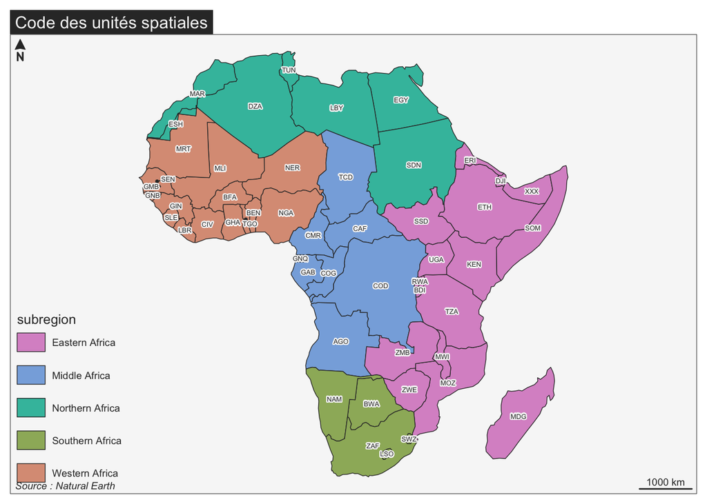

### Utilisation avec Magrit

On peut facilement effectuer des jointures enre le fonds de carte et le jeu de données pour ensuite produire des cartes thématiques.

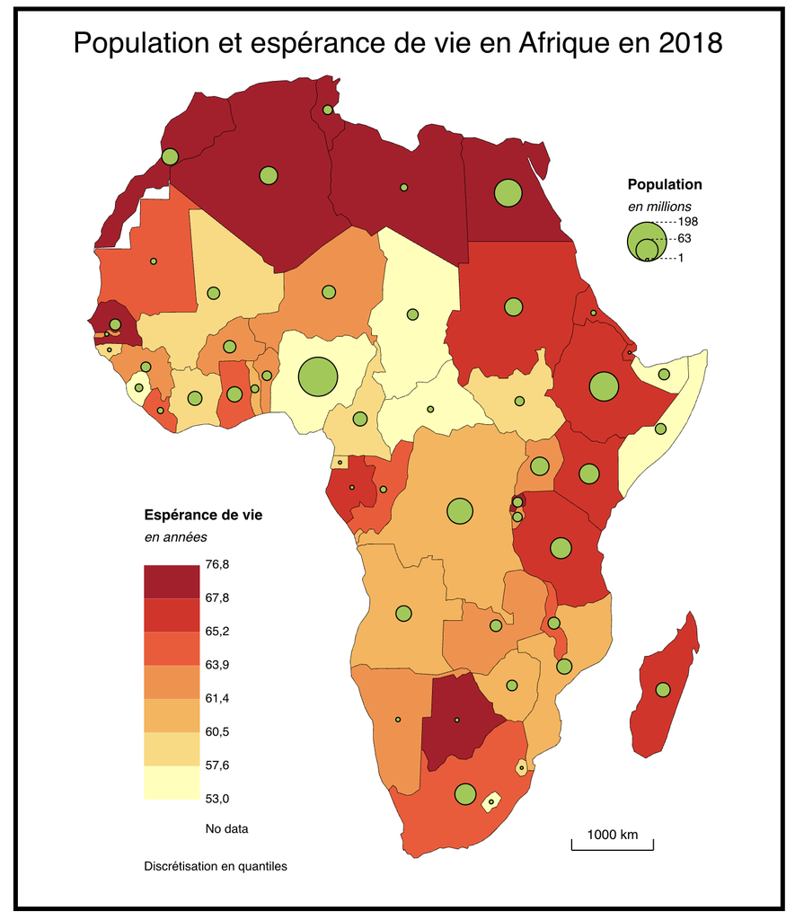